# HW04 Part 2: Complete Chapter 3

Donovan Kleinberg

26 December 2018

```r
library(tidyverse)
```

Data for 1.

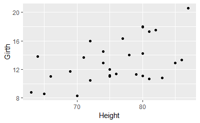

```r
data(trees)
?trees
### Plot 1
ggplot(data = trees, mapping = aes(x =  Height, y = Girth)) +
geom_point()
```

Comments for Plot 1: It appears that there is a slight correlation that as height increases girth increases as well.

Data for 2.

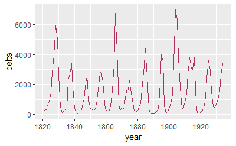

```r
data(lynx)
?lynx
### Plot 2
year <- (1821:1934)
pelts <- as.vector(lynx)
lynx_pelts <- data.frame(year, pelts)
ggplot(data = lynx_pelts, mapping = aes(x = year, y = pelts)) +
  geom_line(color = "maroon")
```

Data for 3.

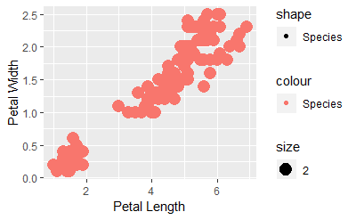

```r
data(iris)
?iris
### Plot 3
ggplot(data = iris, mapping = aes(x = Petal.Length, y = Petal.Width)) +
  geom_point(mapping = aes(color = "Species", shape = "Species", size = 2)) +
  xlab("Petal Length") + ylab("Petal Width")
```

Comments for plot 3: Overall there seems to be a very strong correlation between increasing petal length and increasing petal width. There is also an interesting gap at around the 3 mark for petal length, perhaps a peculiarity of iris plants?

Data for 4 and 5.

```r
msleep
```

| name | genus | vore | order | conservation | sleep_total | sleep_rem | sleep_cycle | awake | brainwt | bodywt |
| --- | --- | --- | --- | --- | --- | --- | --- | --- | --- | --- |
| Cheetah | Acinonyx | carni | Carnivora | lc | 12.1 | NA | NA | 11.90 | NA | 50.000 |
| Owl monkey | Aotus | omni | Primates | NA | 17.0 | 1.8 | NA | 7.00 | 0.01550 | 0.480 |
| Mountain beaver | Aplodontia | herbi | Rodentia | nt | 14.4 | 2.4 | NA | 9.60 | NA | 1.350 |
| Greater short-tailed shrew | Blarina | omni | Soricomorpha | lc | 14.9 | 2.3 | 0.1333333 | 9.10 | 0.00029 | 0.019 |
| Cow | Bos | herbi | Artiodactyla | domesticated | 4.0 | 0.7 | 0.6666667 | 20.00 | 0.42300 | 600.000 |
| Three-toed sloth | Bradypus | herbi | Pilosa | NA | 14.4 | 2.2 | 0.7666667 | 9.60 | NA | 3.850 |
| Northern fur seal | Callorhinus | carni | Carnivora | vu | 8.7 | 1.4 | 0.3833333 | 15.30 | NA | 20.490 |
| Vesper mouse | Calomys | NA | Rodentia | NA | 7.0 | NA | NA | 17.00 | NA | 0.045 |
| Dog | Canis | carni | Carnivora | domesticated | 10.1 | 2.9 | 0.3333333 | 13.90 | 0.07000 | 14.000 |
| Roe deer | Capreolus | herbi | Artiodactyla | lc | 3.0 | NA | NA | 21.00 | 0.09820 | 14.800 |

[output cut: 73 more lines]

```r
?msleep
```

Plots

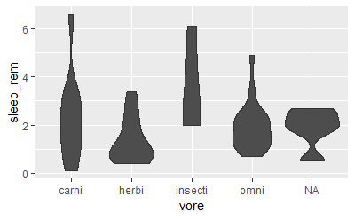

```r
### Plot 4
ggplot(data = msleep) +
  geom_violin(mapping = aes(x = vore, y =sleep_rem), fill = "gray30")
```

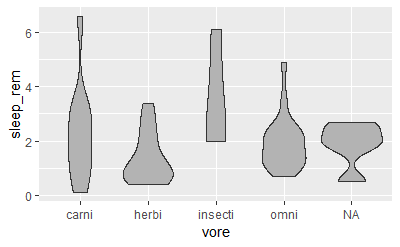

```r
### Plot 5
ggplot(data = msleep) +
  geom_violin(mapping = aes(x = vore, y =sleep_rem), fill = "gray70")
```

Comments for plots 4 and 5: Violin plots show the distribution of data as a shape of varying thickness with thicker portions being where more data is located at. Gray 30 was much darker than Gray 70.

Data for plot 7.

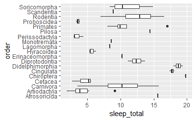

```r
### Plot 7
ggplot(data = msleep, mapping = aes(x = order, y = sleep_total)) +
  geom_boxplot() +
  coord_flip()
```

Comments for plot 7: It appears that some orders of species have much higher variation in the amount of sleep they have compared to other species which have practically no variation.

Data for plot 8.

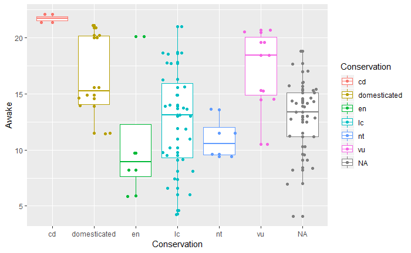

```r
ggplot(data = msleep, mapping = aes(x = conservation, y = awake)) +
  geom_boxplot(mapping = aes(color = conservation)) +
  geom_point(mapping = aes(color = conservation)) +
  geom_jitter(mapping = aes(color = conservation)) +
  xlab("Conservation") + ylab("Awake") +
  scale_color_discrete(name = "Conservation")
```

Comments for plot 8: It seems like there is great variation among conservation types in their periods of being awake.

Data for plots 9 and 10.

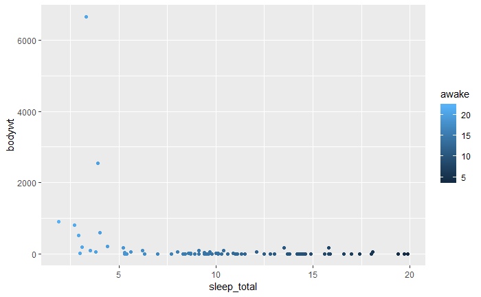

```r
### Plot 9
ggplot(data = msleep, mapping = aes(x = sleep_total, y = bodywt)) +
  geom_point(mapping = aes(color = awake))
```

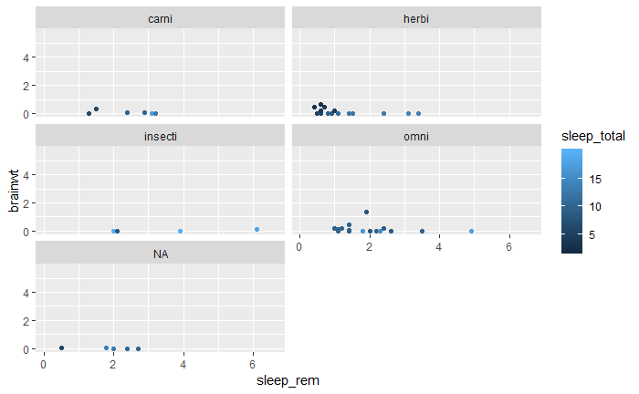

```r
### Plot 10
ggplot(data = msleep, mapping = aes(x = sleep_rem, y = brainwt)) +
  geom_point(mapping = aes(color = sleep_total)) +
  facet_wrap(~vore, ncol = 2)
```

Comments on plot 9: As body weight increases the amount of total sleep appears to be much less.